# Práctica II

Análisis clúster

Ivonne Yañez Mendoza (No poseo DNI, no resido en España) (Universidad Complutense de Madrid)  
2022-07-06

# Instrucciones (leer antes de empezar)

- Modifica dentro del documento `.Rmd` tus datos personales (nombre y DNI) ubicados en la cabecera del archivo.
- Asegúrate antes de seguir editando el documento que el archivo `.Rmd` compila (Knit) correctamente y se genera el `html` correspondiente.
- Los chunks creados están o vacíos o incompletos, de ahí que tengan la opción `eval = FALSE`. Una vez que edites lo que consideres debes de cambiar a `eval = TRUE` para que los chunk se ejecuten

## Paquetes necesarios

Necesitaremos los siguientes paquetes:

- **Manejo de datos**: paquete `{tidyverse}`.
- **Modelos**: paquete `{tidymodels}`
- **Lectura excel**: paquete `{readxl}`
- **Resumen numérico**: paquete `{skimr}`.
- **Visualización de clústers y PCA**: paquete `{factoextra}` y `{FactoMineR}`
- **Clustering divisivo**: paquete `{cluster}`

```r
# Borramos variables del environment
rm(list = ls())
library(tidyverse)
library(tidymodels)
library(readxl)
library(skimr)
library(factoextra)
library(FactoMineR)
library(cluster)
library(corrr)
library(corrplot)
```

# Carga de datos

El archivo de datos a usar será `provincias.xlsx`

```r
provincias <- read_xlsx(path = "./provincias.xlsx")
```

El fichero contiene **información socioeconómica de las provincias españolas**

```r
glimpse(provincias)
```

```
Rows: 52
Columns: 19
$ Prov          <chr> "Albacete", "Alicante", "Almería", "Álava", "A…
$ Poblacion     <dbl> 396987, 1868438, 701688, 321932, 1061756, 6909…
$ Mortalidad    <dbl> 9.41, 8.00, 6.91, 7.72, 12.16, 9.54, 7.08, 8.1…
$ Natalidad     <dbl> 9.02, 8.52, 11.41, 10.26, 6.26, 8.96, 9.51, 9.…
$ IPC           <dbl> 101.819, 102.309, 101.454, 102.743, 102.070, 1…
$ NumEmpresas   <dbl> 26701, 130438, 40327, 19548, 67451, 39640, 871…
$ Industria     <dbl> 3332, 9992, 2191, 2048, 3496, 3059, 4413, 2741…
$ Construccion  <dbl> 3428, 17418, 5388, 2669, 8435, 4599, 14485, 50…
$ CTH           <dbl> 11111, 52720, 18184, 7557, 28045, 18420, 30644…
$ Infor         <dbl> 189, 1851, 366, 323, 787, 332, 1403, 11134, 15…
$ AFS           <dbl> 624, 2745, 944, 354, 1445, 948, 1627, 8829, 16…
$ APT           <dbl> 3278, 19865, 5840, 3341, 10598, 5235, 16444, 8…
$ TasaActividad <dbl> 57.72, 58.21, 60.63, 57.86, 51.42, 56.00, 68.6…
$ TasaParo      <dbl> 23.28, 23.39, 31.08, 13.33, 16.97, 29.63, 13.8…
$ Ocupados      <dbl> 144.8, 687.1, 234.4, 133.0, 389.0, 224.6, 555.…
$ PIB           <dbl> 7235991, 32139347, 11909684, 10716021, 2177043…
$ CANE          <dbl> 20888, 25968, 22945, 3691, 23910, 37438, 10748…
$ TVF           <dbl> 215948, 1274096, 395086, 155767, 613905, 37249…
$ VS            <dbl> 30244, 326705, 72486, 9791, 73250, 49441, 8571…
```

Algunas de las variables son:

- `Prov`: nombre de la provincia
- `Poblacion`: habitantes
- `Mortalidad`, `Natalidad`: tasa de mortalidad/natalidad (en tantos por mil)
- `IPC`: índice de precios de consumo (sobre un valor base de 100).
- `NumEmpresas`: número de empresas.
- `PIB`: producto interior bruto
- `CTH`: coyuntura turística hotelera (pernoctaciones en establecimientos hoteleros)

# Ejercicio 1:

> Calcula la matriz de covarianzas y de correlaciones. Calcula de nuevo la matriz deUsa el paquete `{corrplot}` para una representación gráfica de la misma. Detalla y comenta lo que consideres para su correcta interpretación.

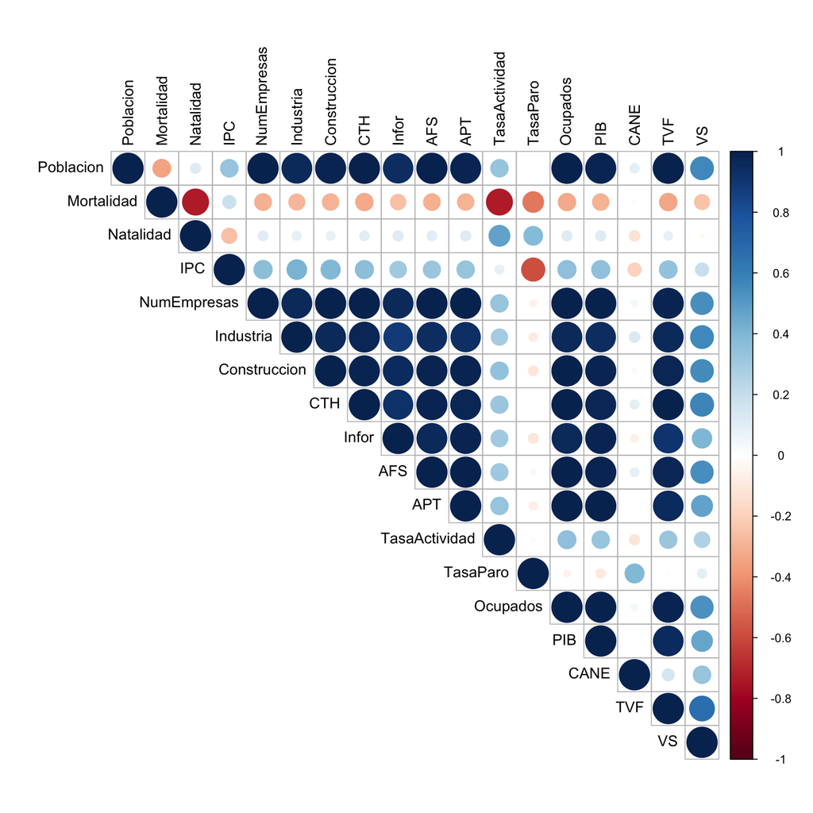

```r
# Completa el código

prov <- provincias %>% select(-Prov)
cov_mat <- cov(prov)

cor_mat <-  prov %>% correlate(diagonal = 1)
#grafico
corrplot(cor(prov), type = "upper", tl.col = "black")
```

```r
cor_mat
```

```
# A tibble: 18 × 19
   term   Poblacion Mortalidad Natalidad     IPC NumEmpresas Industria
   <chr>      <dbl>      <dbl>     <dbl>   <dbl>       <dbl>     <dbl>
 1 Pobla…   1          -0.344     0.114   0.335       0.995     0.965
 2 Morta…  -0.344       1        -0.737   0.188      -0.309    -0.282
 3 Natal…   0.114      -0.737     1      -0.254       0.105     0.0927
 4 IPC      0.335       0.188    -0.254   1           0.365     0.420
 5 NumEm…   0.995      -0.309     0.105   0.365       1         0.969
 6 Indus…   0.965      -0.282     0.0927  0.420       0.969     1
 7 Const…   0.984      -0.296     0.0887  0.400       0.995     0.966
 8 CTH      0.996      -0.329     0.101   0.362       0.994     0.976
 9 Infor    0.945      -0.260     0.115   0.300       0.963     0.889
10 AFS      0.992      -0.305     0.105   0.323       0.993     0.947
11 APT      0.980      -0.296     0.113   0.333       0.991     0.934
12 TasaA…   0.334      -0.733     0.472   0.0897      0.332     0.292
13 TasaP…   0.00985    -0.464     0.383  -0.582      -0.0562   -0.0804
14 Ocupa…   0.996      -0.328     0.112   0.358       0.998     0.962
15 PIB      0.981      -0.296     0.114   0.355       0.990     0.943
16 CANE     0.0972      0.0164   -0.123  -0.191       0.0448    0.124
17 TVF      0.991      -0.332     0.0844  0.341       0.982     0.965
18 VS       0.567      -0.249    -0.0277  0.191       0.540     0.567
# … with 12 more variables: Construccion <dbl>, CTH <dbl>,
#   Infor <dbl>, AFS <dbl>, APT <dbl>, TasaActividad <dbl>,
#   TasaParo <dbl>, Ocupados <dbl>, PIB <dbl>, CANE <dbl>, TVF <dbl>,
#   VS <dbl>
```

# Ejercicio 2:

> Estandariza los datos y guardalos en provincias_std

```r
# Completa el código
provincias_std <- provincias %>%  mutate(across(where(is.numeric), ~scale(.)),seriate = "mean", row_dend_left = TRUE)

provincias_std
```

```
# A tibble: 52 × 21
   Prov      Poblacion[,1] Mortalidad[,1] Natalidad[,1] IPC[,1]
   <chr>             <dbl>          <dbl>         <dbl>   <dbl>
 1 Albacete         -0.435         0.0146        0.0847 -0.648
 2 Alicante          0.839        -0.650        -0.149  -0.0502
 3 Almería          -0.171        -1.16          1.20   -1.09
 4 Álava            -0.500        -0.782         0.664   0.479
 5 Asturias          0.141         1.31         -1.21   -0.342
 6 Badajoz          -0.181         0.0759        0.0566 -1.60
 7 Balears           0.177        -1.08          0.314   2.08
 8 Barcelona         4.01         -0.565         0.375   2.94
 9 Bizkaia           0.219         0.203        -0.135   1.37
10 Burgos           -0.461         0.529        -0.514   1.86
# … with 42 more rows, and 16 more variables: NumEmpresas <dbl[,1]>,
#   Industria <dbl[,1]>, Construccion <dbl[,1]>, CTH <dbl[,1]>,
#   Infor <dbl[,1]>, AFS <dbl[,1]>, APT <dbl[,1]>,
#   TasaActividad <dbl[,1]>, TasaParo <dbl[,1]>, Ocupados <dbl[,1]>,
#   PIB <dbl[,1]>, CANE <dbl[,1]>, TVF <dbl[,1]>, VS <dbl[,1]>,
#   seriate <chr>, row_dend_left <lgl>
```

# Ejercicio 3:

> Calcula con `eigen()` los autovalores y autovectores de la matriz de correlaciones e interpreta dichos resultados en relación a las componentes principales de las variables originales.

```r
# Completa el código
eigen(cor_mat %>% select(-term))
```

```
eigen() decomposition
$values
 [1] 1.146640e+01 2.560508e+00 1.634097e+00 9.340488e-01 4.565320e-01
 [6] 4.143630e-01 3.071743e-01 1.166154e-01 7.309913e-02 2.034496e-02
[11] 9.027568e-03 3.566115e-03 2.372720e-03 8.013952e-04 5.472749e-04
[16] 3.512710e-04 1.028975e-04 4.950858e-05

$vectors
             [,1]         [,2]         [,3]        [,4]         [,5]
 [1,]  0.29352698  0.002493342  0.049947340 -0.05339540 -0.015898841
 [2,] -0.10629199 -0.527120141  0.188867032 -0.16131678  0.024146585
 [3,]  0.04062702  0.495419403 -0.270681171 -0.10967036 -0.382061614
 [4,]  0.10991169 -0.365322291 -0.262317619  0.43504738 -0.556757431
 [5,]  0.29418239 -0.026147510  0.007952241 -0.06913798 -0.006367061
 [6,]  0.28562283 -0.044737470  0.046369149  0.02345108 -0.150042973
```

[output cut: 88 more lines]

# Ejercicio 4:

> Haciendo uso de `PCA()` del paquete `{FactoMineR}` calcula todas las componentes principales. Repite de nuevo el análisis con el mínimo número de componentes necesairas para capturar al menos el 95% de la información de los datos.

```r
# Completa el código
# PCA con todo
provincias_full <- provincias %>% select(-Prov)
provincias_fit <-
  PCA(provincias_full, scale.unit = TRUE, ncp = ncol(provincias_full), graph = FALSE)
provincias_fit$eig
```

```
          eigenvalue percentage of variance
comp 1  1.146640e+01           6.370222e+01
comp 2  2.560508e+00           1.422504e+01
comp 3  1.634097e+00           9.078315e+00
comp 4  9.340488e-01           5.189160e+00
comp 5  4.565320e-01           2.536289e+00
comp 6  4.143630e-01           2.302017e+00
comp 7  3.071743e-01           1.706524e+00
comp 8  1.166154e-01           6.478631e-01
comp 9  7.309913e-02           4.061063e-01
comp 10 2.034496e-02           1.130275e-01
comp 11 9.027568e-03           5.015315e-02
comp 12 3.566115e-03           1.981175e-02
comp 13 2.372720e-03           1.318178e-02
comp 14 8.013952e-04           4.452195e-03
comp 15 5.472749e-04           3.040416e-03
comp 16 3.512710e-04           1.951506e-03
comp 17 1.028975e-04           5.716530e-04
comp 18 4.950858e-05           2.750477e-04
        cumulative percentage of variance
comp 1                           63.70222
comp 2                           77.92726
comp 3                           87.00558
comp 4                           92.19474
comp 5                           94.73102
comp 6                           97.03304
comp 7                           98.73957
comp 8                           99.38743
comp 9                           99.79353
comp 10                          99.90656
comp 11                          99.95672
comp 12                          99.97653
comp 13                          99.98971
comp 14                          99.99416
comp 15                          99.99720
comp 16                          99.99915
comp 17                          99.99972
comp 18                         100.00000
```

```r
#Solo con 7 componentes
provincias_fit <-
  PCA(provincias_full, scale.unit = TRUE, ncp = 7, graph = FALSE)

provincias_fit$var$contrib
```

```
                   Dim.1        Dim.2        Dim.3       Dim.4
Poblacion     8.61580869 6.216756e-04 2.494737e-01  0.28510690
Mortalidad    1.12979868 2.778556e+01 3.567076e+00  2.60231048
Natalidad     0.16505544 2.454404e+01 7.326830e+00  1.20275871
IPC           1.20805785 1.334604e+01 6.881053e+00 18.92662230
NumEmpresas   8.65432772 6.836923e-02 6.323813e-03  0.47800598
Industria     8.15804006 2.001441e-01 2.150098e-01  0.05499531
Construccion  8.60042932 2.059505e-01 1.459770e-02  0.06966501
CTH           8.57705398 1.127314e-02 2.385458e-01  0.07607058
Infor         7.92433313 1.765523e-01 4.178363e-01  4.90741583
AFS           8.55363151 2.707409e-02 1.564543e-01  0.84054061
APT           8.45209684 8.663137e-02 7.878255e-02  2.01245468
TasaActividad 1.30730170 1.093060e+01 1.315763e+01 21.44167757
TasaParo      0.01958975 2.130396e+01 1.500454e+01  4.84888573
Ocupados      8.66880711 2.835454e-02 5.901685e-04  0.36063054
PIB           8.46269279 1.307379e-01 1.405631e-01  1.78508842
CANE          0.03164342 9.251454e-01 4.313115e+01  7.75029908
TVF           8.50111166 2.558733e-04 9.952426e-01  0.19487506
VS            2.97022035 2.286851e-01 8.418293e+00 32.16259720
                     Dim.5        Dim.6        Dim.7
Poblacion     2.527731e-02  0.008577510  0.453944293
Mortalidad    5.830576e-02  0.113808680  3.786678534
Natalidad     1.459711e+01  9.825724095 34.577279772
IPC           3.099788e+01 12.301662219 10.785093429
NumEmpresas   4.053946e-03  0.004628499  0.027361631
Industria     2.251289e+00  0.379668213  0.419007777
Construccion  6.583274e-03  0.003921397  0.070969785
CTH           8.046371e-02  0.223154480  0.464317190
Infor         4.960879e-01  1.577980441  0.263865387
AFS           9.251174e-04  0.299366263  0.034286589
APT           1.006972e-01  0.640893842  0.006486645
TasaActividad 1.770063e+00 27.932330747  3.462400720
TasaParo      3.065031e-01  9.253743706 34.975747546
Ocupados      1.518964e-04  0.159122519  0.055008212
PIB           7.434893e-03  0.593372087  0.008014071
CANE          2.381808e+01 17.575176869  3.985286690
TVF           2.178721e-01  0.543501985  0.003119205
VS            2.526122e+01 18.563366447  6.621132525
```

# Ejercicio 5:

> Realiza las gráficas que consideres más útiles para poder interpretar adecuadamente las componentes principales obtenidas. ¿Cuál es la expresión para calcular la primera componente en función de las variables originales?

```r
# Completa el código
```

# Ejercicio 6:

> ¿Cuál es la contribución de las variables originales en cada componente principal seleccionada? Proporciona las nuevas coordenadas de los datos. ¿Cuál de las variables es la que está peor explicada?

```r
# Completa el código
```

# Ejercicio 7:

> Si tuviéramos que construir un índice que valore de forma conjunta el desarrollo económico de una provincia, como se podría construir utilizando una combinación lineal de todas las variables. ¿Cuál sería el valor de dicho índice en Madrid? ¿Cual sería su valor en Melilla?

```r
# Completa el código
```

# Ejercicio 8:

> Calcula la matriz de distancias de los datos. Representa un mapa de calor de la matriz de datos, estandarizado y sin estandarizar, así como de la matriz de distancias. Comenta si se detectan inicialmente grupos de provincias.

```r
# Completa el código
```

# Ejercicio 9:

> Realiza varios análisis de clúster jerárquico con distintos enlaces y comenta las diferencias. En cada caso visualiza el dendograma y comenta cuántos clusters recomendarías usar.

```r
# Completa el código
```

# Ejercicio 10:

> ¿Qué número óptimo de clusters nos indican los criterios Silhoutte y de Elbow? Representar los individuos agrupados según el número de clusters elegido.

```r
# Completa el código
```

# Ejercicio 11:

> Con el número de clusters decidido en el apartado anterior realizar un agrupamiento no jerárquico de k-medias. Representar los clusters formados en los planos de las Componentes principales. Interpreta los resultados y evalúa la calidad del análisis clúster. Explica las provincias que forman cada uno de los clusters y comentar cuales son las características socioeconómicas que las hacen pertenecer a dicho cluster

```r
# Completa el código
```